# Life Expectancy Analysis

Nikhil Gupta

11/15/2021

# **INTRODUCTION** :

Life Expectancy of human life has been one of the central idea behind various researches and increasing it has been a constant effort of humanity.Thus, understanding the available data about it as well as various parameters that effect the life expectancy becomes increasingly important. In light of this notion, this study is trying to fundamentally analyse the available LIfe expectancy data as well as make suggestions on how we can try to improve it by influencing various primary and secondary parameters associated with it. This study will focus on immunization factors, mortality factors, economic factors, social factors and other health related factors as well. Since the observations this dataset are based on different countries, it will be easier for a country to determine the predicting factor which is contributing to lower value of life expectancy. This will help in suggesting a country which area should be given importance in order to efficiently improve the life expectancy of its population.

# **DATA SOURCE** :

This given data has been sourced from the data repository of *Kaggle*.

url : *https://www.kaggle.com/kumarajarshi/life-expectancy-who*

This dataset related to life expectancy, health factors for 193 countries has been collected from the The Global Health Observatory (GHO) data repository under World Health Organization (WHO) and its corresponding economic data was collected from United Nation website. Among all categories of health-related factors only those critical factors were chosen which are more representative. It has been observed that in the 15 years period ranging from 2000-2015 , there has been a huge development in health sector resulting in improvement of human mortality rates especially in the developing nations in comparison to the past 30 years. Therefore, in this project we have considered data from year 2000-2015 for 193 countries for further analysis. The individual data files have been merged together into a single dataset. All predicting variables was then divided into several broad categories:Immunization related factors, Mortality factors, Economical factors and Social factors.

# **QUESTIONS OF INTEREST** :

The data-set aims to answer the following key questions: -Compare the life expectancy trends of Developed world and Developing world.

-Does various predicting factors which has been chosen initially really affect the Life expectancy? What are the predicting variables actually affecting the life expectancy?

-Does Life Expectancy has positive or negative correlation with eating habits, lifestyle, exercise, smoking, drinking alcohol etc.

-How does mortality factors like Infant and Adult mortality rates affect life expectancy?

-What is the impact of Immunization coverage on life Expectancy?

-What is the impact of increased health spending on the lifespan of humans?Analyse the relationship of various economic factors vis-a-vis Life Expectancy.

-Find the mean life expectancy for all the people across globe, averaged over the given time period ?

-Top 10 countries with highest and Least Life expectancy across globe ?

-Probability density function of global Avg. Life Expectancies to find most likely L.E. for world countries.

-Country-wise comparison of top performers : in terms of LIfe Expectancy

-Linear Model to predict Life expectancy against the parameter of schooling

# **DETAILED STATISTICAL ANALYSIS** :

## Importing relevant *libraries*

```r
library(readr)
library(httr)
library(tidyverse)
library(lubridate)
```

```r
library(dplyr)
library(ggplot2)
library(readr)
```

## Importing the *data* for Analysis

```r
data<- read_csv( "Life Expectancy Data.csv",show_col_types = FALSE)
data
```

```
## # A tibble: 2,938 x 22
##    Country      Year Status     `Life expectanc~ `Adult Mortalit~ `infant deaths`
##    <chr>       <dbl> <chr>                 <dbl>            <dbl>           <dbl>
##  1 Afghanistan  2015 Developing             65                263              62
##  2 Afghanistan  2014 Developing             59.9              271              64
##  3 Afghanistan  2013 Developing             59.9              268              66
##  4 Afghanistan  2012 Developing             59.5              272              69
##  5 Afghanistan  2011 Developing             59.2              275              71
##  6 Afghanistan  2010 Developing             58.8              279              74
##  7 Afghanistan  2009 Developing             58.6              281              77
##  8 Afghanistan  2008 Developing             58.1              287              80
##  9 Afghanistan  2007 Developing             57.5              295              82
## 10 Afghanistan  2006 Developing             57.3              295              84
## # ... with 2,928 more rows, and 16 more variables: Alcohol <dbl>,
## #   percentage expenditure <dbl>, Hepatitis B <dbl>, Measles <dbl>, BMI <dbl>,
## #   under-five deaths <dbl>, Polio <dbl>, Total expenditure <dbl>,
## #   Diphtheria <dbl>, HIV/AIDS <dbl>, GDP <dbl>, Population <dbl>,
## #   thinness  1-19 years <dbl>, thinness 5-9 years <dbl>,
## #   Income composition of resources <dbl>, Schooling <dbl>
```

## Understanding the Data-set

We are looking at the tibble and the summary statistics to get more insight about the data such as size of data, quantum of data, nature of data (clean/unclean). The above results indicates that some of the data entries are missing or N/A. The most of the missing data was for population, Hepatitis B and GDP. The missing data were from less known countries like Vanuatu, Tonga, Togo,Cabo Verde etc.The final merged file(final dataset) consists of 22 Columns and 2938 rows which meant 20 predicting variables.

```r
summary(data)
```

```
##    Country               Year         Status          Life expectancy
##  Length:2938        Min.   :2000   Length:2938        Min.   :36.30
##  Class :character   1st Qu.:2004   Class :character   1st Qu.:63.10
##  Mode  :character   Median :2008   Mode  :character   Median :72.10
##                     Mean   :2008                      Mean   :69.22
##                     3rd Qu.:2012                      3rd Qu.:75.70
##                     Max.   :2015                      Max.   :89.00
##                                                       NA's   :10
##  Adult Mortality infant deaths       Alcohol        percentage expenditure
##  Min.   :  1.0   Min.   :   0.0   Min.   : 0.0100   Min.   :    0.000
##  1st Qu.: 74.0   1st Qu.:   0.0   1st Qu.: 0.8775   1st Qu.:    4.685
##  Median :144.0   Median :   3.0   Median : 3.7550   Median :   64.913
##  Mean   :164.8   Mean   :  30.3   Mean   : 4.6029   Mean   :  738.251
##  3rd Qu.:228.0   3rd Qu.:  22.0   3rd Qu.: 7.7025   3rd Qu.:  441.534
##  Max.   :723.0   Max.   :1800.0   Max.   :17.8700   Max.   :19479.912
##  NA's   :10                       NA's   :194
##   Hepatitis B       Measles              BMI        under-five deaths
##  Min.   : 1.00   Min.   :     0.0   Min.   : 1.00   Min.   :   0.00
##  1st Qu.:77.00   1st Qu.:     0.0   1st Qu.:19.30   1st Qu.:   0.00
##  Median :92.00   Median :    17.0   Median :43.50   Median :   4.00
##  Mean   :80.94   Mean   :  2419.6   Mean   :38.32   Mean   :  42.04
##  3rd Qu.:97.00   3rd Qu.:   360.2   3rd Qu.:56.20   3rd Qu.:  28.00
##  Max.   :99.00   Max.   :212183.0   Max.   :87.30   Max.   :2500.00
##  NA's   :553                        NA's   :34
##      Polio       Total expenditure   Diphtheria       HIV/AIDS
##  Min.   : 3.00   Min.   : 0.370    Min.   : 2.00   Min.   : 0.100
##  1st Qu.:78.00   1st Qu.: 4.260    1st Qu.:78.00   1st Qu.: 0.100
##  Median :93.00   Median : 5.755    Median :93.00   Median : 0.100
##  Mean   :82.55   Mean   : 5.938    Mean   :82.32   Mean   : 1.742
##  3rd Qu.:97.00   3rd Qu.: 7.492    3rd Qu.:97.00   3rd Qu.: 0.800
##  Max.   :99.00   Max.   :17.600    Max.   :99.00   Max.   :50.600
##  NA's   :19      NA's   :226       NA's   :19
##       GDP              Population        thinness  1-19 years
##  Min.   :     1.68   Min.   :3.400e+01   Min.   : 0.10
##  1st Qu.:   463.94   1st Qu.:1.958e+05   1st Qu.: 1.60
##  Median :  1766.95   Median :1.387e+06   Median : 3.30
##  Mean   :  7483.16   Mean   :1.275e+07   Mean   : 4.84
##  3rd Qu.:  5910.81   3rd Qu.:7.420e+06   3rd Qu.: 7.20
##  Max.   :119172.74   Max.   :1.294e+09   Max.   :27.70
##  NA's   :448         NA's   :652         NA's   :34
##  thinness 5-9 years Income composition of resources   Schooling
##  Min.   : 0.10      Min.   :0.0000                  Min.   : 0.00
##  1st Qu.: 1.50      1st Qu.:0.4930                  1st Qu.:10.10
##  Median : 3.30      Median :0.6770                  Median :12.30
##  Mean   : 4.87      Mean   :0.6276                  Mean   :11.99
##  3rd Qu.: 7.20      3rd Qu.:0.7790                  3rd Qu.:14.30
##  Max.   :28.60      Max.   :0.9480                  Max.   :20.70
##  NA's   :34         NA's   :167                     NA's   :163
```

## **Cleaning** the data set

looking at the *summary of the data* to see if there are any problems. Summary statistics show that there are many rows which contain NA values.Hence, cleaning the data by deleting the rows which contain NA’s.

```r
data_clean <-na.omit(data)
print(data_clean)
```

```
## # A tibble: 1,649 x 22
##    Country      Year Status     `Life expectanc~ `Adult Mortalit~ `infant deaths`
##    <chr>       <dbl> <chr>                 <dbl>            <dbl>           <dbl>
##  1 Afghanistan  2015 Developing             65                263              62
##  2 Afghanistan  2014 Developing             59.9              271              64
##  3 Afghanistan  2013 Developing             59.9              268              66
##  4 Afghanistan  2012 Developing             59.5              272              69
##  5 Afghanistan  2011 Developing             59.2              275              71
##  6 Afghanistan  2010 Developing             58.8              279              74
##  7 Afghanistan  2009 Developing             58.6              281              77
##  8 Afghanistan  2008 Developing             58.1              287              80
##  9 Afghanistan  2007 Developing             57.5              295              82
## 10 Afghanistan  2006 Developing             57.3              295              84
## # ... with 1,639 more rows, and 16 more variables: Alcohol <dbl>,
## #   percentage expenditure <dbl>, Hepatitis B <dbl>, Measles <dbl>, BMI <dbl>,
## #   under-five deaths <dbl>, Polio <dbl>, Total expenditure <dbl>,
## #   Diphtheria <dbl>, HIV/AIDS <dbl>, GDP <dbl>, Population <dbl>,
## #   thinness  1-19 years <dbl>, thinness 5-9 years <dbl>,
## #   Income composition of resources <dbl>, Schooling <dbl>
```

## Understanding the **Clean Data**

Clearly, the summary of the clean data shows that there are no more missing data fields.Though the minimum value for certain attributes are still 0, but 0 is a possible minimum value for those columns. Hence assuming zero to be the part of data and retaining them in the clean dataset. After cleaning the datasets, the final cleaned tibble contains 1649 rows with 22 columns. To get some more insight into the clean data, looking at the summary statistics.

```r
summary(data_clean)
```

```
##    Country               Year         Status          Life expectancy
##  Length:1649        Min.   :2000   Length:1649        Min.   :44.0
##  Class :character   1st Qu.:2005   Class :character   1st Qu.:64.4
##  Mode  :character   Median :2008   Mode  :character   Median :71.7
##                     Mean   :2008                      Mean   :69.3
##                     3rd Qu.:2011                      3rd Qu.:75.0
##                     Max.   :2015                      Max.   :89.0
##  Adult Mortality infant deaths        Alcohol       percentage expenditure
##  Min.   :  1.0   Min.   :   0.00   Min.   : 0.010   Min.   :    0.00
##  1st Qu.: 77.0   1st Qu.:   1.00   1st Qu.: 0.810   1st Qu.:   37.44
##  Median :148.0   Median :   3.00   Median : 3.790   Median :  145.10
##  Mean   :168.2   Mean   :  32.55   Mean   : 4.533   Mean   :  698.97
##  3rd Qu.:227.0   3rd Qu.:  22.00   3rd Qu.: 7.340   3rd Qu.:  509.39
##  Max.   :723.0   Max.   :1600.00   Max.   :17.870   Max.   :18961.35
##   Hepatitis B       Measles            BMI        under-five deaths
##  Min.   : 2.00   Min.   :     0   Min.   : 2.00   Min.   :   0.00
##  1st Qu.:74.00   1st Qu.:     0   1st Qu.:19.50   1st Qu.:   1.00
##  Median :89.00   Median :    15   Median :43.70   Median :   4.00
##  Mean   :79.22   Mean   :  2224   Mean   :38.13   Mean   :  44.22
##  3rd Qu.:96.00   3rd Qu.:   373   3rd Qu.:55.80   3rd Qu.:  29.00
##  Max.   :99.00   Max.   :131441   Max.   :77.10   Max.   :2100.00
##      Polio       Total expenditure   Diphtheria       HIV/AIDS
##  Min.   : 3.00   Min.   : 0.740    Min.   : 2.00   Min.   : 0.100
##  1st Qu.:81.00   1st Qu.: 4.410    1st Qu.:82.00   1st Qu.: 0.100
##  Median :93.00   Median : 5.840    Median :92.00   Median : 0.100
##  Mean   :83.56   Mean   : 5.956    Mean   :84.16   Mean   : 1.984
##  3rd Qu.:97.00   3rd Qu.: 7.470    3rd Qu.:97.00   3rd Qu.: 0.700
##  Max.   :99.00   Max.   :14.390    Max.   :99.00   Max.   :50.600
##       GDP              Population        thinness  1-19 years
##  Min.   :     1.68   Min.   :3.400e+01   Min.   : 0.100
##  1st Qu.:   462.15   1st Qu.:1.919e+05   1st Qu.: 1.600
##  Median :  1592.57   Median :1.420e+06   Median : 3.000
##  Mean   :  5566.03   Mean   :1.465e+07   Mean   : 4.851
##  3rd Qu.:  4718.51   3rd Qu.:7.659e+06   3rd Qu.: 7.100
##  Max.   :119172.74   Max.   :1.294e+09   Max.   :27.200
##  thinness 5-9 years Income composition of resources   Schooling
##  Min.   : 0.100     Min.   :0.0000                  Min.   : 4.20
##  1st Qu.: 1.700     1st Qu.:0.5090                  1st Qu.:10.30
##  Median : 3.200     Median :0.6730                  Median :12.30
##  Mean   : 4.908     Mean   :0.6316                  Mean   :12.12
##  3rd Qu.: 7.100     3rd Qu.:0.7510                  3rd Qu.:14.00
##  Max.   :28.200     Max.   :0.9360                  Max.   :20.70
```

## ** Data Visualization and Analysis**

In order to answer the above mentioned questions of interest,we will be going through various visualizations along with their subsequent analysis in a orderly manner.

### Comparing the life expectancy of Developed world and Developing world

```r
data_global_trend <- data_clean %>% group_by(Year,Status)%>% select(-c(Country))%>% summarise_each(funs( mean( .,na.rm = TRUE)))%>%ungroup()
ungroup(data_clean)
```

```
## # A tibble: 1,649 x 22
##    Country      Year Status     `Life expectanc~ `Adult Mortalit~ `infant deaths`
##    <chr>       <dbl> <chr>                 <dbl>            <dbl>           <dbl>
##  1 Afghanistan  2015 Developing             65                263              62
##  2 Afghanistan  2014 Developing             59.9              271              64
##  3 Afghanistan  2013 Developing             59.9              268              66
##  4 Afghanistan  2012 Developing             59.5              272              69
##  5 Afghanistan  2011 Developing             59.2              275              71
##  6 Afghanistan  2010 Developing             58.8              279              74
##  7 Afghanistan  2009 Developing             58.6              281              77
##  8 Afghanistan  2008 Developing             58.1              287              80
##  9 Afghanistan  2007 Developing             57.5              295              82
## 10 Afghanistan  2006 Developing             57.3              295              84
## # ... with 1,639 more rows, and 16 more variables: Alcohol <dbl>,
## #   percentage expenditure <dbl>, Hepatitis B <dbl>, Measles <dbl>, BMI <dbl>,
## #   under-five deaths <dbl>, Polio <dbl>, Total expenditure <dbl>,
## #   Diphtheria <dbl>, HIV/AIDS <dbl>, GDP <dbl>, Population <dbl>,
## #   thinness  1-19 years <dbl>, thinness 5-9 years <dbl>,
## #   Income composition of resources <dbl>, Schooling <dbl>
```

```r
print(data_global_trend)
```

```
## # A tibble: 31 x 21
##     Year Status     `Life expectancy` `Adult Mortality` `infant deaths` Alcohol
##    <dbl> <chr>                  <dbl>             <dbl>           <dbl>   <dbl>
##  1  2000 Developed               76.1              91.7            1.38   10.6
##  2  2000 Developing              68.6             197.            26.7     3.76
##  3  2001 Developed               76.6              84.9            1.29   10.4
##  4  2001 Developing              68.6             181.            25.8     3.85
##  5  2002 Developed               76.9              94.9            1.29   10.7
##  6  2002 Developing              66.9             188.            25.7     3.81
##  7  2003 Developed               77.2              78.9            1.07   10.6
##  8  2003 Developing              66.7             191.            30.2     3.59
##  9  2004 Developed               77.9              87.8            1.07   10.9
## 10  2004 Developing              66.8             201.            45.7     3.67
## # ... with 21 more rows, and 15 more variables: percentage expenditure <dbl>,
## #   Hepatitis B <dbl>, Measles <dbl>, BMI <dbl>, under-five deaths <dbl>,
## #   Polio <dbl>, Total expenditure <dbl>, Diphtheria <dbl>, HIV/AIDS <dbl>,
## #   GDP <dbl>, Population <dbl>, thinness  1-19 years <dbl>,
## #   thinness 5-9 years <dbl>, Income composition of resources <dbl>,
## #   Schooling <dbl>
```

#### Plotting the avg. Life expectancy trend for Developed Vs Developing.

Below is the plot of Avg. Life Expectancy of developed nations Vs developing nations, averaged over the past few years (2000-2015) period .

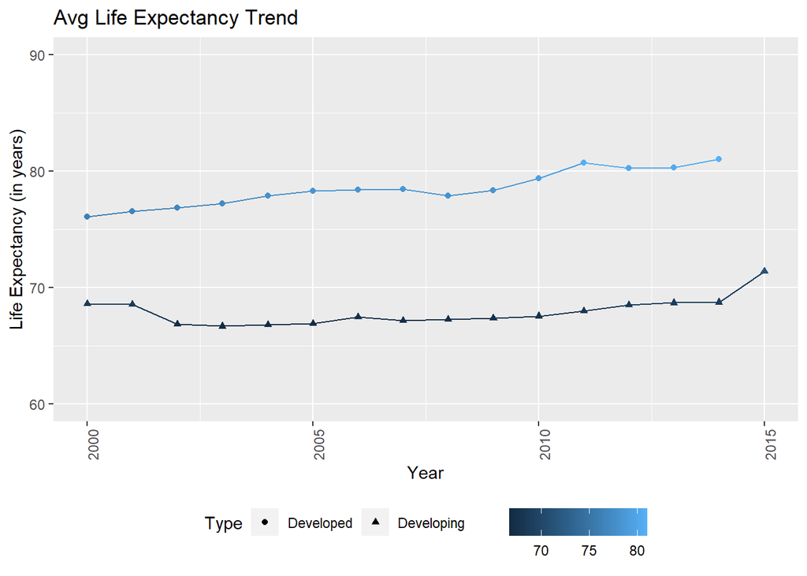

```r
data_global_trend %>%
  ggplot(aes(x = Year, y = `Life expectancy`)) +
  geom_line(aes(color = data_global_trend$`Life expectancy`, shape = data_global_trend$Status)) +
  geom_point(aes(color = data_global_trend$`Life expectancy`, shape = data_global_trend$Status)) +
  labs(shape = "Type", color = NULL)+
  ylim(60,90)+
  theme(legend.position="bottom",
        axis.text.x = element_text(angle = 90)) +
  labs(title = "Avg Life Expectancy Trend", y= "Life Expectancy (in years)" )
```

#### Analyzing the above plots.

As can be seen from the Plots, following observations are made : - Life expectancy of developed countries is significantly higher than developing countries (almost 10yr higher). - Though both developed and developing countries have shown an increase in Life expectancy but the increase is higher for developed countries as compared to developing countries. - Even the maximun Life expectancy for developing countries is lower than the least Life expectancy of developed countries.

Lets cross-check the observations with the summary statistics.

```r
developed<- data_global_trend %>% filter (Status == "Developed")%>% select(Year,`Life expectancy`)
developing<-data_global_trend %>% filter (Status == "Developing")%>% select(Year, `Life expectancy`)
summary(developed)
```

```
##       Year      Life expectancy
##  Min.   :2000   Min.   :76.08
##  1st Qu.:2004   1st Qu.:77.55
##  Median :2007   Median :78.34
##  Mean   :2007   Mean   :78.52
##  3rd Qu.:2010   3rd Qu.:79.83
##  Max.   :2014   Max.   :81.03
```

```r
summary(developing)
```

```
##       Year      Life expectancy
##  Min.   :2000   Min.   :66.68
##  1st Qu.:2004   1st Qu.:67.11
##  Median :2008   Median :67.51
##  Mean   :2008   Mean   :67.92
##  3rd Qu.:2011   3rd Qu.:68.57
##  Max.   :2015   Max.   :71.40
```

The summary statistics are also in tune with the observations of the Plots, with min. and Max. values of Life Expectancy as follows:

Developed : 76.08 to 81.03 Developing : 66.68 to 71.40 Gap b/w the two : approx: 10yrs